# IDS 575: MILESTONE REPORT

Team Members:

Utkarsh Ujwal Email: uujwal2@uic.edu UIN: 659563524

Rahul Dhanasiri Email: rdhana4@uic.edu UIN: 650749738

Chakradhaar Viswatmula Email: cviswa2@uic.edu UIN:657723905

# Feedback Response (Project Proposal)

We received the following feedback and have highlighted our response to some of your concerns. Do get back to us with any additional follow up questions or suggestions or if you think anything is inaccurate or inadequate.

“I am not sure if your classification problem is appropriately set up. When you plan to learn the “value of a player”, what is your timeframe. A player might be initially an average player, then after a couple of weeks become a budding talent, and then again become an average player. What is your plan to model the temporal change of the value of a player? (2) Who is the audience of your project? Is there any business that benefits from your paper? How? (3) What is a potential way to incorporate the budget constraint in a supervised learning problem? Do you have any specific candidate model that can handle such a constraint?”

FIFA stats are updated real time. We use this dataset taken at the beginning of the 2019 season. The value of a player is decided by the team he has a contract with. His value might vary based on his performance during the course of the season but that data would be updated on FIFA as well. We would just have to have captured data at a specific point and look at his statistics to make decisions with a model using that data instance.

FIFA data is based on real players with real time updates. The audience of our project could vary from simple players of the FIFA console/PC games to actual football managers or even fantasy football players (By football here I mean soccer). The business benefits could be to actually sell a detailed system to football clubs to use for various statistical analyses and finding replacements for players on their teams, etc.

We want to try and use clustering algorithms like KNN to find like for like replacements for players based on budget constraints. We will hard code the constraints to find only those points which match our requirements.

# Motivation for your problem

We as sports enthusiasts follow soccer and play FIFA a lot ourselves. Thinking of the possibility of integrating soccer into our course seems exciting by itself but the possibilities in addition to that, like picking like for like replacements for a team, building a team of the best 11 with a specific budget, having a significant advantage while playing manager mode on FIFA with statistical knowledge, etc

Although we’re not going to incorporate all these problems in our project, we hope we are allowed to present flexible outcomes based on trial and error and feasibility.

```python
import numpy as np
import pandas as pd
import matplotlib.pyplot as plt
%matplotlib inline
import seaborn as sns
```

```python
# Ignore Warnings
import warnings
warnings.filterwarnings('ignore')
```

```python
fifa = pd.read_csv('/Users/utkarshujwal/Desktop/Semester 1/IDS_575/Final project/Data/data.csv',index_col=0)
```

```python
fifa.head().describe()
```

|  | ID | Age | Overall | Potential | Special | International Reputation | Weak Foot | Skill Moves | Jersey Number | Crossing | ... | Penalties | Composure | Marking | StandingTackle | SlidingTackle | GKDiving | GKHandling | GKKicking | GKPositioning | GKReflexes |
| --- | --- | --- | --- | --- | --- | --- | --- | --- | --- | --- | --- | --- | --- | --- | --- | --- | --- | --- | --- | --- | --- |
| count | 5.000000 | 5.00000 | 5.000000 | 5.00000 | 5.000000 | 5.000000 | 5.00000 | 5.000000 | 5.000000 | 5.000000 | ... | 5.000000 | 5.00000 | 5.000000 | 5.000000 | 5.000000 | 5.000000 | 5.000000 | 5.000000 | 5.000000 | 5.000000 |
| mean | 151152.000000 | 28.80000 | 92.400000 | 93.20000 | 2065.000000 | 4.600000 | 4.20000 | 3.800000 | 7.000000 | 71.400000 | ... | 72.000000 | 88.20000 | 34.200000 | 32.400000 | 29.200000 | 25.400000 | 25.800000 | 27.400000 | 28.200000 | 27.400000 |
| std | 74370.945059 | 3.03315 | 1.516575 | 0.83666 | 335.750652 | 0.547723 | 0.83666 | 1.643168 | 3.674235 | 30.826936 | ... | 18.248288 | 11.71324 | 20.017492 | 14.808781 | 14.149205 | 36.280849 | 33.124009 | 33.597619 | 33.484325 | 37.273315 |
| min | 20801.000000 | 26.00000 | 91.000000 | 92.00000 | 1471.000000 | 4.000000 | 3.00000 | 1.000000 | 1.000000 | 17.000000 | ... | 40.000000 | 68.00000 | 15.000000 | 21.000000 | 13.000000 | 6.000000 | 9.000000 | 5.000000 | 10.000000 | 8.000000 |
| 25% | 158023.000000 | 27.00000 | 91.000000 | 93.00000 | 2143.000000 | 4.000000 | 4.00000 | 4.000000 | 7.000000 | 79.000000 | ... | 75.000000 | 88.00000 | 27.000000 | 24.000000 | 23.000000 | 7.000000 | 11.000000 | 15.000000 | 14.000000 | 11.000000 |
| 50% | 190871.000000 | 27.00000 | 92.000000 | 93.00000 | 2202.000000 | 5.000000 | 4.00000 | 4.000000 | 7.000000 | 84.000000 | ... | 79.000000 | 94.00000 | 28.000000 | 28.000000 | 26.000000 | 9.000000 | 11.000000 | 15.000000 | 14.000000 | 11.000000 |
| 75% | 192985.000000 | 31.00000 | 94.000000 | 94.00000 | 2228.000000 | 5.000000 | 5.00000 | 5.000000 | 10.000000 | 84.000000 | ... | 81.000000 | 95.00000 | 33.000000 | 31.000000 | 33.000000 | 15.000000 | 13.000000 | 15.000000 | 15.000000 | 13.000000 |
| max | 193080.000000 | 33.00000 | 94.000000 | 94.00000 | 2281.000000 | 5.000000 | 5.00000 | 5.000000 | 10.000000 | 93.000000 | ... | 85.000000 | 96.00000 | 68.000000 | 58.000000 | 51.000000 | 90.000000 | 85.000000 | 87.000000 | 88.000000 | 94.000000 |

8 rows × 43 columns

```python
fifa.describe()
```

|  | ID | Age | Overall | Potential | Special | International Reputation | Weak Foot | Skill Moves | Jersey Number | Crossing | ... | Penalties | Composure | Marking | StandingTackle | SlidingTackle | GKDiving | GKHandling | GKKicking | GKPositioning | GKReflexes |
| --- | --- | --- | --- | --- | --- | --- | --- | --- | --- | --- | --- | --- | --- | --- | --- | --- | --- | --- | --- | --- | --- |
| count | 18207.000000 | 18207.000000 | 18207.000000 | 18207.000000 | 18207.000000 | 18159.000000 | 18159.000000 | 18159.000000 | 18147.000000 | 18159.000000 | ... | 18159.000000 | 18159.000000 | 18159.000000 | 18159.000000 | 18159.000000 | 18159.000000 | 18159.000000 | 18159.000000 | 18159.000000 | 18159.000000 |
| mean | 214298.338606 | 25.122206 | 66.238699 | 71.307299 | 1597.809908 | 1.113222 | 2.947299 | 2.361308 | 19.546096 | 49.734181 | ... | 48.548598 | 58.648274 | 47.281623 | 47.697836 | 45.661435 | 16.616223 | 16.391596 | 16.232061 | 16.388898 | 16.710887 |
| std | 29965.244204 | 4.669943 | 6.908930 | 6.136496 | 272.586016 | 0.394031 | 0.660456 | 0.756164 | 15.947765 | 18.364524 | ... | 15.704053 | 11.436133 | 19.904397 | 21.664004 | 21.289135 | 17.695349 | 16.906900 | 16.502864 | 17.034669 | 17.955119 |
| min | 16.000000 | 16.000000 | 46.000000 | 48.000000 | 731.000000 | 1.000000 | 1.000000 | 1.000000 | 1.000000 | 5.000000 | ... | 5.000000 | 3.000000 | 3.000000 | 2.000000 | 3.000000 | 1.000000 | 1.000000 | 1.000000 | 1.000000 | 1.000000 |
| 25% | 200315.500000 | 21.000000 | 62.000000 | 67.000000 | 1457.000000 | 1.000000 | 3.000000 | 2.000000 | 8.000000 | 38.000000 | ... | 39.000000 | 51.000000 | 30.000000 | 27.000000 | 24.000000 | 8.000000 | 8.000000 | 8.000000 | 8.000000 | 8.000000 |
| 50% | 221759.000000 | 25.000000 | 66.000000 | 71.000000 | 1635.000000 | 1.000000 | 3.000000 | 2.000000 | 17.000000 | 54.000000 | ... | 49.000000 | 60.000000 | 53.000000 | 55.000000 | 52.000000 | 11.000000 | 11.000000 | 11.000000 | 11.000000 | 11.000000 |
| 75% | 236529.500000 | 28.000000 | 71.000000 | 75.000000 | 1787.000000 | 1.000000 | 3.000000 | 3.000000 | 26.000000 | 64.000000 | ... | 60.000000 | 67.000000 | 64.000000 | 66.000000 | 64.000000 | 14.000000 | 14.000000 | 14.000000 | 14.000000 | 14.000000 |
| max | 246620.000000 | 45.000000 | 94.000000 | 95.000000 | 2346.000000 | 5.000000 | 5.000000 | 5.000000 | 99.000000 | 93.000000 | ... | 92.000000 | 96.000000 | 94.000000 | 93.000000 | 91.000000 | 90.000000 | 92.000000 | 91.000000 | 90.000000 | 94.000000 |

8 rows × 43 columns

```python
fifa.info()
```

[output not shown]

```python
set_nb_theme('grade3')
```

DATA Exploration for FIFA 19

```python
# Null Values
fifa.isnull().mean()>0.6
```

```
ID                          False
Name                        False
Age                         False
Photo                       False
Nationality                 False
Flag                        False
Overall                     False
Potential                   False
Club                        False
Club Logo                   False
Value                       False
Wage                        False
Special                     False
Preferred Foot              False
International Reputation    False
Weak Foot                   False
Skill Moves                 False
Work Rate                   False
Body Type                   False
Real Face                   False
Position                    False
Jersey Number               False
Joined                      False
Loaned From                  True
Contract Valid Until        False
Height                      False
Weight                      False
LS                          False
ST                          False
RS                          False
                            ...
Dribbling                   False
Curve                       False
FKAccuracy                  False
LongPassing                 False
BallControl                 False
Acceleration                False
SprintSpeed                 False
Agility                     False
Reactions                   False
Balance                     False
ShotPower                   False
Jumping                     False
Stamina                     False
Strength                    False
LongShots                   False
Aggression                  False
Interceptions               False
Positioning                 False
Vision                      False
Penalties                   False
Composure                   False
Marking                     False
StandingTackle              False
SlidingTackle               False
GKDiving                    False
GKHandling                  False
GKKicking                   False
GKPositioning               False
GKReflexes                  False
Release Clause              False
Length: 88, dtype: bool
```

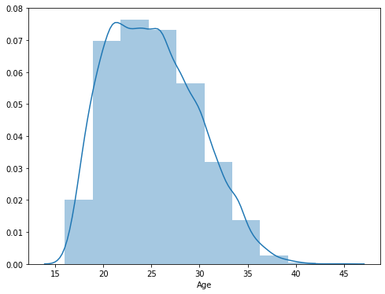

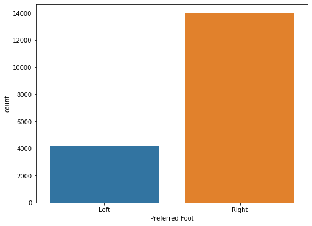

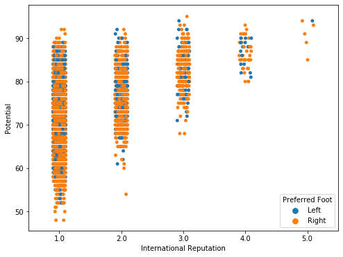

```python
# Visualisations

#Exploring each variable

# AGE

fig,axes = plt.subplots(figsize=(8,6))
x= fifa['Age']
ax= sns.distplot(x, bins=10)
plt.show()

# Preferred Foot
fig,axes = plt.subplots(figsize=(8,6))
sns.countplot(x= "Preferred Foot", data= fifa)
plt.show()


# International reputaion with potential(categorical)
fig,axes =  plt.subplots(figsize=(8, 6))
sns.stripplot(x="International Reputation", y="Potential",hue="Preferred Foot",  data=fifa)
plt.show()
```

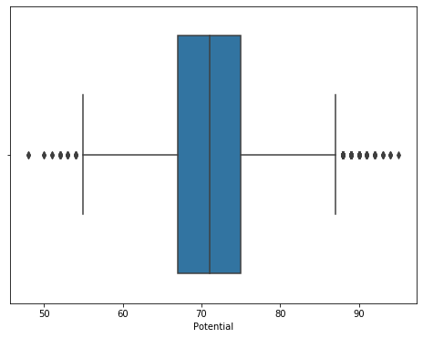

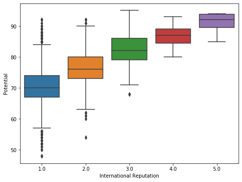

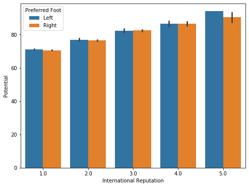

```python
# Box plots

#Potential

f,ax = plt.subplots(figsize=(8,6))
sns.boxplot(x=fifa["Potential"])
plt.show()

#Internatioanl reputation vs potential
f,ax = plt.subplots(figsize=(8,6))
sns.boxplot(x="International Reputation", y= "Potential", data=fifa)
plt.show()

#Barplot
f,ax = plt.subplots(figsize=(8,6))
sns.barplot(x="International Reputation", y= "Potential",hue= "Preferred Foot",  data=fifa)
plt.show()
```

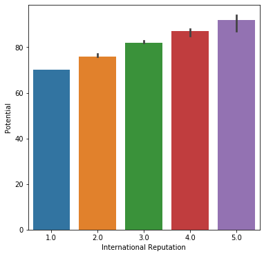

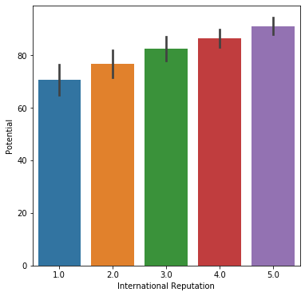

|  | ID | Age | Overall | Potential | Special | International Reputation | Weak Foot | Skill Moves | Jersey Number | Crossing | ... | Marking | StandingTackle | SlidingTackle | GKDiving | GKHandling | GKKicking | GKPositioning | GKReflexes | Value in Pounds | Wage in Pounds |
| --- | --- | --- | --- | --- | --- | --- | --- | --- | --- | --- | --- | --- | --- | --- | --- | --- | --- | --- | --- | --- | --- |
| ID | 1.000000 | -0.739208 | -0.417025 | 0.047074 | -0.231352 | -0.356191 | -0.075784 | -0.056914 | 0.182074 | -0.131994 | ... | -0.110198 | -0.085929 | -0.068409 | -0.105594 | -0.111149 | -0.106652 | -0.118250 | -0.105778 | -0.138194 | -0.204610 |
| Age | -0.739208 | 1.000000 | 0.452350 | -0.253312 | 0.236695 | 0.253765 | 0.059867 | 0.027649 | -0.241156 | 0.130545 | ... | 0.142817 | 0.119745 | 0.103089 | 0.101277 | 0.106419 | 0.104964 | 0.116402 | 0.103313 | 0.075022 | 0.141145 |
| Overall | -0.417025 | 0.452350 | 1.000000 | 0.660939 | 0.606960 | 0.499491 | 0.212015 | 0.414463 | -0.218931 | 0.394972 | ... | 0.286505 | 0.252629 | 0.222811 | -0.025937 | -0.025062 | -0.029372 | -0.017674 | -0.023276 | 0.627085 | 0.571926 |
| Potential | 0.047074 | -0.253312 | 0.660939 | 1.000000 | 0.383727 | 0.372993 | 0.162346 | 0.354290 | -0.010474 | 0.246319 | ... | 0.162801 | 0.143564 | 0.128980 | -0.053446 | -0.054672 | -0.059061 | -0.052589 | -0.053341 | 0.576218 | 0.486413 |
| Special | -0.231352 | 0.236695 | 0.606960 | 0.383727 | 1.000000 | 0.292208 | 0.341855 | 0.763412 | -0.133716 | 0.866417 | ... | 0.561866 | 0.538802 | 0.506968 | -0.674637 | -0.673625 | -0.670254 | -0.668272 | -0.673238 | 0.377738 | 0.347835 |
| International Reputation | -0.356191 | 0.253765 | 0.499491 | 0.372993 | 0.292208 | 1.000000 | 0.128317 | 0.208153 | -0.077298 | 0.191770 | ... | 0.115208 | 0.092846 | 0.079176 | 0.004526 | 0.003942 | 0.000651 | 0.006904 | 0.003444 | 0.653176 | 0.668635 |
| Weak Foot | -0.075784 | 0.059867 | 0.212015 | 0.162346 | 0.341855 | 0.128317 | 1.000000 | 0.340721 | -0.035410 | 0.307925 | ... | 0.065673 | 0.042646 | 0.026105 | -0.231905 | -0.233098 | -0.229395 | -0.231298 | -0.232574 | 0.165221 | 0.140849 |
| Skill Moves | -0.056914 | 0.027649 | 0.414463 | 0.354290 | 0.763412 | 0.208153 | 0.340721 | 1.000000 | -0.035194 | 0.741035 | ... | 0.241428 | 0.210517 | 0.178607 | -0.621675 | -0.619755 | -0.616990 | -0.618853 | -0.621925 | 0.315651 | 0.263205 |
| Jersey Number | 0.182074 | -0.241156 | -0.218931 | -0.010474 | -0.133716 | -0.077298 | -0.035410 | -0.035194 | 1.000000 | -0.076585 | ... | -0.142474 | -0.133285 | -0.124610 | 0.004807 | 0.001543 | 0.001162 | -0.002736 | 0.003255 | -0.095132 | -0.086561 |
| Crossing | -0.131994 | 0.130545 | 0.394972 | 0.246319 | 0.866417 | 0.191770 | 0.307925 | 0.741035 | -0.076585 | 1.000000 | ... | 0.443101 | 0.428963 | 0.409961 | -0.663053 | -0.660193 | -0.659767 | -0.660160 | -0.662539 | 0.249785 | 0.232834 |
| Finishing | -0.082323 | 0.068660 | 0.332515 | 0.243355 | 0.724244 | 0.178373 | 0.357416 | 0.743439 | -0.006639 | 0.655300 | ... | 0.024218 | -0.033023 | -0.071811 | -0.588752 | -0.587145 | -0.583268 | -0.584852 | -0.586913 | 0.256665 | 0.217439 |
| HeadingAccuracy | -0.106815 | 0.147183 | 0.340776 | 0.200988 | 0.644421 | 0.157483 | 0.183238 | 0.443005 | -0.091688 | 0.469507 | ... | 0.583123 | 0.561063 | 0.533643 | -0.750417 | -0.749888 | -0.746444 | -0.744443 | -0.748895 | 0.184437 | 0.187967 |
| ShortPassing | -0.136279 | 0.132894 | 0.502550 | 0.369189 | 0.906729 | 0.242803 | 0.322133 | 0.730363 | -0.100241 | 0.809660 | ... | 0.559576 | 0.541131 | 0.508644 | -0.729785 | -0.728024 | -0.724381 | -0.723782 | -0.728721 | 0.327623 | 0.296691 |
| Volleys | -0.159915 | 0.142472 | 0.391338 | 0.254906 | 0.773974 | 0.243089 | 0.357340 | 0.745077 | -0.026731 | 0.690339 | ... | 0.120919 | 0.072788 | 0.035457 | -0.590808 | -0.588668 | -0.584954 | -0.586131 | -0.588670 | 0.288243 | 0.257357 |
| Dribbling | -0.030340 | 0.010166 | 0.372426 | 0.315019 | 0.874274 | 0.179041 | 0.352658 | 0.839757 | -0.028021 | 0.856647 | ... | 0.336072 | 0.301251 | 0.273963 | -0.754625 | -0.753181 | -0.749816 | -0.751348 | -0.754341 | 0.272004 | 0.237150 |
| Curve | -0.169511 | 0.143276 | 0.419491 | 0.279944 | 0.851900 | 0.233681 | 0.345468 | 0.771052 | -0.055428 | 0.833105 | ... | 0.289529 | 0.261481 | 0.232869 | -0.606286 | -0.603141 | -0.600266 | -0.603540 | -0.604960 | 0.287235 | 0.259550 |
| FKAccuracy | -0.199549 | 0.193467 | 0.396892 | 0.230544 | 0.806414 | 0.223564 | 0.330472 | 0.701068 | -0.068843 | 0.761107 | ... | 0.297976 | 0.279153 | 0.247903 | -0.556605 | -0.553644 | -0.549911 | -0.552641 | -0.554920 | 0.265773 | 0.236385 |
| LongPassing | -0.186764 | 0.181310 | 0.483909 | 0.321437 | 0.846302 | 0.239525 | 0.277174 | 0.622342 | -0.117424 | 0.756527 | ... | 0.587106 | 0.587430 | 0.562230 | -0.596820 | -0.594999 | -0.591453 | -0.591561 | -0.595887 | 0.302175 | 0.276762 |
| BallControl | -0.100184 | 0.084969 | 0.460197 | 0.354396 | 0.912107 | 0.217946 | 0.356383 | 0.818051 | -0.073210 | 0.840916 | ... | 0.452705 | 0.417566 | 0.384802 | -0.788444 | -0.786797 | -0.783423 | -0.783607 | -0.787939 | 0.308818 | 0.277615 |
| Acceleration | 0.133236 | -0.158667 | 0.196869 | 0.234608 | 0.654337 | 0.044319 | 0.261435 | 0.652356 | -0.004395 | 0.668365 | ... | 0.195369 | 0.163000 | 0.157565 | -0.593008 | -0.594866 | -0.592127 | -0.592143 | -0.593201 | 0.170603 | 0.124985 |
| SprintSpeed | 0.132437 | -0.151682 | 0.210647 | 0.236771 | 0.645963 | 0.044070 | 0.248822 | 0.624098 | -0.015069 | 0.645578 | ... | 0.212575 | 0.178214 | 0.171980 | -0.597677 | -0.599694 | -0.597320 | -0.596498 | -0.597837 | 0.172677 | 0.130315 |
| Agility | -0.019897 | -0.019395 | 0.264952 | 0.222310 | 0.699673 | 0.100869 | 0.302062 | 0.681765 | -0.034158 | 0.698320 | ... | 0.167122 | 0.129204 | 0.116686 | -0.527756 | -0.528482 | -0.527164 | -0.526983 | -0.528899 | 0.194259 | 0.156287 |
| Reactions | -0.408617 | 0.453124 | 0.850045 | 0.513425 | 0.597169 | 0.445614 | 0.201341 | 0.377044 | -0.192622 | 0.389574 | ... | 0.283607 | 0.255399 | 0.228355 | -0.062967 | -0.061940 | -0.065927 | -0.055031 | -0.059961 | 0.540552 | 0.495560 |
| Balance | 0.048463 | -0.089877 | 0.103160 | 0.138025 | 0.586788 | 0.050076 | 0.254022 | 0.578459 | 0.008009 | 0.618280 | ... | 0.178695 | 0.154045 | 0.152470 | -0.504727 | -0.506102 | -0.503970 | -0.503652 | -0.505974 | 0.113726 | 0.088873 |
| ShotPower | -0.166133 | 0.156947 | 0.441118 | 0.288318 | 0.835277 | 0.227772 | 0.332855 | 0.718237 | -0.053860 | 0.705503 | ... | 0.296944 | 0.256403 | 0.220237 | -0.654117 | -0.654099 | -0.649403 | -0.651409 | -0.653475 | 0.281360 | 0.258351 |
| Jumping | -0.169369 | 0.177167 | 0.264435 | 0.109151 | 0.321846 | 0.120931 | 0.069752 | 0.107553 | -0.104179 | 0.135486 | ... | 0.279196 | 0.260645 | 0.260261 | -0.192700 | -0.193692 | -0.195282 | -0.189079 | -0.192050 | 0.124515 | 0.129691 |
| Stamina | -0.053895 | 0.097793 | 0.365656 | 0.202563 | 0.792762 | 0.094780 | 0.232094 | 0.570226 | -0.127822 | 0.672633 | ... | 0.587782 | 0.570055 | 0.544702 | -0.701467 | -0.698556 | -0.696729 | -0.696073 | -0.699670 | 0.210721 | 0.177562 |
| Strength | -0.259756 | 0.332798 | 0.349326 | 0.075769 | 0.192990 | 0.131280 | -0.008470 | -0.041475 | -0.158411 | -0.029403 | ... | 0.333334 | 0.332159 | 0.304849 | -0.111012 | -0.109660 | -0.110253 | -0.103878 | -0.107497 | 0.128924 | 0.139360 |
| LongShots | -0.161549 | 0.155096 | 0.420795 | 0.266740 | 0.840049 | 0.213960 | 0.355967 | 0.752980 | -0.046174 | 0.742065 | ... | 0.215510 | 0.172331 | 0.133603 | -0.612381 | -0.610739 | -0.605952 | -0.607200 | -0.610087 | 0.279730 | 0.249084 |
| Aggression | -0.228329 | 0.265190 | 0.395470 | 0.171174 | 0.666236 | 0.173327 | 0.131524 | 0.347795 | -0.146907 | 0.473570 | ... | 0.723961 | 0.744216 | 0.721384 | -0.575843 | -0.576114 | -0.573607 | -0.571201 | -0.575142 | 0.184639 | 0.194581 |
| Interceptions | -0.160602 | 0.197845 | 0.321326 | 0.154908 | 0.561676 | 0.129586 | 0.053097 | 0.209604 | -0.158526 | 0.427739 | ... | 0.888349 | 0.941471 | 0.928282 | -0.485585 | -0.486324 | -0.485394 | -0.481279 | -0.486036 | 0.140666 | 0.157415 |
| Positioning | -0.088330 | 0.082443 | 0.356493 | 0.245616 | 0.824307 | 0.183003 | 0.346896 | 0.781248 | -0.025422 | 0.783185 | ... | 0.202597 | 0.158060 | 0.124228 | -0.679480 | -0.677699 | -0.674393 | -0.675569 | -0.678582 | 0.259391 | 0.226775 |
| Vision | -0.215170 | 0.187422 | 0.498894 | 0.348141 | 0.761992 | 0.284600 | 0.337897 | 0.674057 | -0.078050 | 0.684948 | ... | 0.176760 | 0.146460 | 0.113228 | -0.381899 | -0.377807 | -0.374737 | -0.375775 | -0.381158 | 0.357639 | 0.315395 |
| Penalties | -0.140657 | 0.139535 | 0.341429 | 0.224281 | 0.734533 | 0.218620 | 0.330252 | 0.690434 | -0.028023 | 0.645805 | ... | 0.152296 | 0.101920 | 0.066693 | -0.620069 | -0.618968 | -0.614006 | -0.617074 | -0.619099 | 0.239033 | 0.222440 |
| Composure | -0.384473 | 0.391023 | 0.727655 | 0.440008 | 0.752331 | 0.392787 | 0.278132 | 0.586836 | -0.167523 | 0.575446 | ... | 0.384081 | 0.351726 | 0.317492 | -0.378750 | -0.375720 | -0.374897 | -0.370234 | -0.377626 | 0.450352 | 0.419597 |
| Marking | -0.110198 | 0.142817 | 0.286505 | 0.162801 | 0.561866 | 0.115208 | 0.065673 | 0.241428 | -0.142474 | 0.443101 | ... | 1.000000 | 0.906541 | 0.895908 | -0.550978 | -0.552263 | -0.549498 | -0.546670 | -0.551290 | 0.133862 | 0.145594 |
| StandingTackle | -0.085929 | 0.119745 | 0.252629 | 0.143564 | 0.538802 | 0.092846 | 0.042646 | 0.210517 | -0.133285 | 0.428963 | ... | 0.906541 | 1.000000 | 0.974659 | -0.530989 | -0.532160 | -0.531092 | -0.527792 | -0.531474 | 0.108402 | 0.126291 |
| SlidingTackle | -0.068409 | 0.103089 | 0.222811 | 0.128980 | 0.506968 | 0.079176 | 0.026105 | 0.178607 | -0.124610 | 0.409961 | ... | 0.895908 | 0.974659 | 1.000000 | -0.509337 | -0.510591 | -0.509378 | -0.505792 | -0.509425 | 0.087735 | 0.111025 |
| GKDiving | -0.105594 | 0.101277 | -0.025937 | -0.053446 | -0.674637 | 0.004526 | -0.231905 | -0.621675 | 0.004807 | -0.663053 | ... | -0.550978 | -0.530989 | -0.509337 | 1.000000 | 0.970280 | 0.965685 | 0.969864 | 0.973320 | -0.028596 | -0.025595 |
| GKHandling | -0.111149 | 0.106419 | -0.025062 | -0.054672 | -0.673625 | 0.003942 | -0.233098 | -0.619755 | 0.001543 | -0.660193 | ... | -0.552263 | -0.532160 | -0.510591 | 0.970280 | 1.000000 | 0.965239 | 0.969408 | 0.970264 | -0.028894 | -0.025177 |
| GKKicking | -0.106652 | 0.104964 | -0.029372 | -0.059061 | -0.670254 | 0.000651 | -0.229395 | -0.616990 | 0.001162 | -0.659767 | ... | -0.549498 | -0.531092 | -0.509378 | 0.965685 | 0.965239 | 1.000000 | 0.964336 | 0.966337 | -0.030923 | -0.028325 |
| GKPositioning | -0.118250 | 0.116402 | -0.017674 | -0.052589 | -0.668272 | 0.006904 | -0.231298 | -0.618853 | -0.002736 | -0.660160 | ... | -0.546670 | -0.527792 | -0.505792 | 0.969864 | 0.969408 | 0.964336 | 1.000000 | 0.970130 | -0.027892 | -0.025489 |
| GKReflexes | -0.105778 | 0.103313 | -0.023276 | -0.053341 | -0.673238 | 0.003444 | -0.232574 | -0.621925 | 0.003255 | -0.662539 | ... | -0.551290 | -0.531474 | -0.509425 | 0.973320 | 0.970264 | 0.966337 | 0.970130 | 1.000000 | -0.028544 | -0.025992 |
| Value in Pounds | -0.138194 | 0.075022 | 0.627085 | 0.576218 | 0.377738 | 0.653176 | 0.165221 | 0.315651 | -0.095132 | 0.249785 | ... | 0.133862 | 0.108402 | 0.087735 | -0.028596 | -0.028894 | -0.030923 | -0.027892 | -0.028544 | 1.000000 | 0.858442 |
| Wage in Pounds | -0.204610 | 0.141145 | 0.571926 | 0.486413 | 0.347835 | 0.668635 | 0.140849 | 0.263205 | -0.086561 | 0.232834 | ... | 0.145594 | 0.126291 | 0.111025 | -0.025595 | -0.025177 | -0.028325 | -0.025489 | -0.025992 | 0.858442 | 1.000000 |

45 rows × 45 columns

```python
# Descriptive Statistics

from numpy import median
f, ax = plt.subplots(figsize=(6, 6))
sns.barplot(x="International Reputation", y="Potential", data=fifa, estimator=median)
plt.show()


f, ax = plt.subplots(figsize=(6, 6))
sns.barplot(x="International Reputation", y="Potential", data=fifa, ci="sd")
plt.show()


#Correlation bewteen variables
fifa.corr()
```

Visualising Statistical relationships

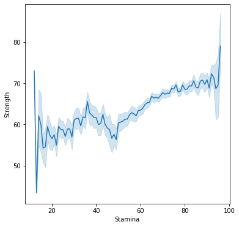

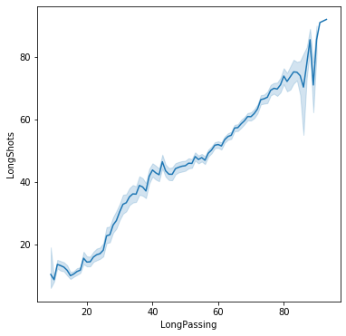

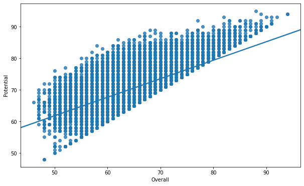

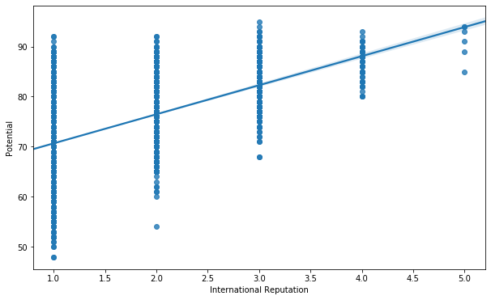

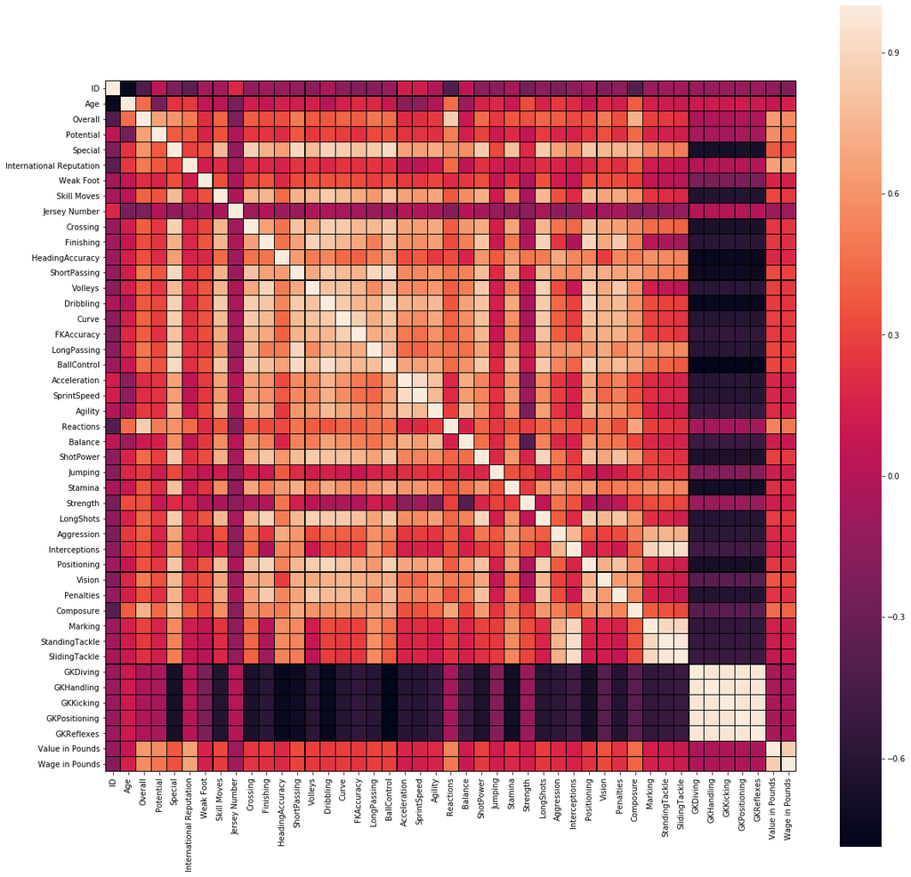

```python
# Statima vs Strength

fig, ax = plt.subplots(figsize=(6, 6))
ax = sns.lineplot(x="Stamina", y="Strength", data=fifa)
plt.show()


#Long pass vs long shot

fig, ax = plt.subplots(figsize=(6, 6))
ax = sns.lineplot(x="LongPassing", y="LongShots", data=fifa)
plt.show()


#Overall vs potential

fig, ax = plt.subplots(figsize=(10, 6))
ax = sns.regplot(x="Overall", y="Potential", data=fifa)
plt.show()


#Interantional reputation and potential

fig, ax = plt.subplots(figsize=(10, 6))
sns.regplot(x="International Reputation", y="Potential", data=fifa)
plt.show()


# Drawing a Correlation heatmap between different attributes

plt.figure(figsize=(20,20))
sns.heatmap(fifa.corr(),linewidths=0.1,linecolor='black',square=True)
```

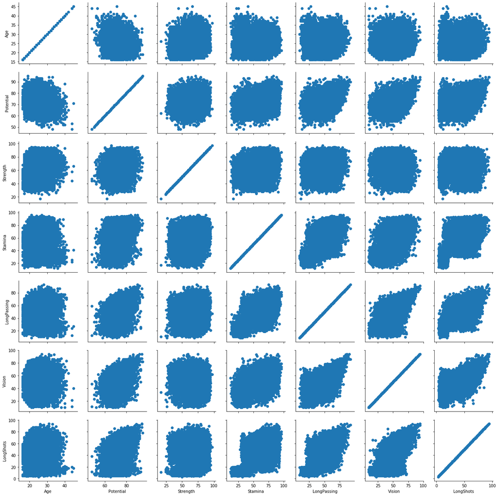

```python
# Let us check pairwise relationship betwenn attributes in the dataset

fifa_new = fifa[['Age', 'Potential', 'Strength', 'Stamina', 'Preferred Foot','LongPassing','Vision'
                ,'LongShots']]

pair = sns.PairGrid(fifa_new)
pair = pair.map(plt.scatter)
```

DATA EXPLORATION

```python
# Countries with highest number of players
print('Total number of countries : {0}'. format(fifa['Nationality'].nunique()))
print(fifa['Nationality'].value_counts().head(5))
```

```
Total number of countries : 164
England      1662
Germany      1198
Spain        1072
Argentina     937
France        914
Name: Nationality, dtype: int64
```

```python
# Total number of clubs and clubs with highest number of players
print('Total number of clubs : {0}'. format(fifa['Club'].nunique()))
print(fifa['Club'].value_counts().head(5))
```

```
Total number of clubs : 651
Eintracht Frankfurt    33
FC Barcelona           33
Rayo Vallecano         33
Liverpool              33
Chelsea                33
Name: Club, dtype: int64
```

```python
#Changing data types
fifa.select_dtypes(include=object).columns


def wageConverter(val):
    if val[-1] == 'M':
        val = val[1:-1]
        val = float(val) * 1000000
        return val

    elif val[-1] == 'K':
        val = val[1:-1]
        val = float(val) * 1000
        return val

    else:
        return 0


fifa['Value in Pounds'] = fifa['Value'].apply(wageConverter)
fifa['Wage in Pounds'] = fifa['Wage'].apply(wageConverter)

fifa.drop(columns=['Value', 'Wage'], inplace=True)
```

```python
fifa.head()
```

|  | ID | Name | Age | Photo | Nationality | Flag | Overall | Potential | Club | Club Logo | ... | StandingTackle | SlidingTackle | GKDiving | GKHandling | GKKicking | GKPositioning | GKReflexes | Release Clause | Value in Pounds | Wage in Pounds |
| --- | --- | --- | --- | --- | --- | --- | --- | --- | --- | --- | --- | --- | --- | --- | --- | --- | --- | --- | --- | --- | --- |
| 0 | 158023 | L. Messi | 31 | https://cdn.sofifa.org/players/4/19/158023.png | Argentina | https://cdn.sofifa.org/flags/52.png | 94 | 94 | FC Barcelona | https://cdn.sofifa.org/teams/2/light/241.png | ... | 28.0 | 26.0 | 6.0 | 11.0 | 15.0 | 14.0 | 8.0 | €226.5M | 110500000.0 | 565000.0 |
| 1 | 20801 | Cristiano Ronaldo | 33 | https://cdn.sofifa.org/players/4/19/20801.png | Portugal | https://cdn.sofifa.org/flags/38.png | 94 | 94 | Juventus | https://cdn.sofifa.org/teams/2/light/45.png | ... | 31.0 | 23.0 | 7.0 | 11.0 | 15.0 | 14.0 | 11.0 | €127.1M | 77000000.0 | 405000.0 |
| 2 | 190871 | Neymar Jr | 26 | https://cdn.sofifa.org/players/4/19/190871.png | Brazil | https://cdn.sofifa.org/flags/54.png | 92 | 93 | Paris Saint-Germain | https://cdn.sofifa.org/teams/2/light/73.png | ... | 24.0 | 33.0 | 9.0 | 9.0 | 15.0 | 15.0 | 11.0 | €228.1M | 118500000.0 | 290000.0 |
| 3 | 193080 | De Gea | 27 | https://cdn.sofifa.org/players/4/19/193080.png | Spain | https://cdn.sofifa.org/flags/45.png | 91 | 93 | Manchester United | https://cdn.sofifa.org/teams/2/light/11.png | ... | 21.0 | 13.0 | 90.0 | 85.0 | 87.0 | 88.0 | 94.0 | €138.6M | 72000000.0 | 260000.0 |
| 4 | 192985 | K. De Bruyne | 27 | https://cdn.sofifa.org/players/4/19/192985.png | Belgium | https://cdn.sofifa.org/flags/7.png | 91 | 92 | Manchester City | https://cdn.sofifa.org/teams/2/light/10.png | ... | 58.0 | 51.0 | 15.0 | 13.0 | 5.0 | 10.0 | 13.0 | €196.4M | 102000000.0 | 355000.0 |

5 rows × 88 columns

```python
fifa[['Height','Weight']].head()

#We need to remove the lbs from weight and convert height to cms
def height_conv(x):
    f = x.split("'")[0]
    i = x.split("'")[1]
    h = (int(f) * 30.48) + (int(i)*2.54)
    return h

def weight_conv(x):
    w = int(x.split('lbs')[0])
    return w

fifa['Height in Cms'] = fifa['Height'].apply(height_conv)
fifa['Weight in Pounds'] = fifa['Weight'].apply(weight_conv)

fifa.drop(columns=['Height', 'Weight'], inplace=True)
fifa[['Height in Cms', 'Weight in Pounds']].head()
```

[output not shown]

```python
fifa.select_dtypes(include=object).columns
```

[output not shown]